# Diversity Metrics Analysis Script

**K.M.Purcell**  
email

## Data

### Fishery-independent

The datasets for this analysis derive from both fishery-dependent and fishery-indepedent data sets. The fishery-independent data was derived from the SEAMAP survey data. Data was downloaded on 2013-7-3, from the Gulf States Marine Fisheries online SEAMAP [access](http://seamap.gsmfc.org/) website. We used several tables from their Access database with parameters including:

```r
names(starec.dat)
```

```
##  [1] "STATIONID"  "CRUISEID"   "VESSEL"     "CRUISE_NO"  "P_STA_NO"
##  [6] "TIME_ZN"    "TIME_MIL"   "DEPTH_SSTA" "S_STA_NO"   "MO_DAY_YR"
## [11] "TIME_EMIL"  "DEPTH_ESTA" "GEARS"      "TEMP_SSURF" "TEMP_BOT"
## [16] "TEMP_SAIR"  "B_PRSSR"    "WIND_SPD"   "WIND_DIR"   "WAVE_HT"
## [21] "SEA_COND"   "VESSEL_SPD" "FAUN_ZONE"  "STAT_ZONE"  "TOW_NO"
## [26] "NET_NO"     "DECSLAT"    "DECSLON"    "DECELAT"    "DECELON"
## [31] "START_DATE" "END_DATE"   "HAULVALUE"  "date"       "month"
## [36] "YR"
```

```r
names(envrec.dat)
```

```
##  [1] "ENVRECID"   "CRUISEID"   "STATIONID"  "VESSEL"     "CRUISE_NO"
##  [6] "P_STA_NO"   "CLD_TYPE"   "CLD_COVER"  "SECCHI_DSK" "WECOLOR"
## [11] "STA_LOC"    "PRECIP"     "DEPTH_ESRF" "DEPTH_EMID" "DEPTH_EMAX"
## [16] "DEPTH_EWTR" "TEMPSURF"   "TEMPMID"    "TEMPMAX"    "SALSURF"
## [21] "SALMID"     "SALMAX"     "CHLORSURF"  "CHLORMID"   "CHLORMAX"
## [26] "OXYSURF"    "OXYMID"     "OXYMAX"     "TURBSURF"   "TURBMID"
## [31] "TURBMAX"
```

```r
names(invrec.dat)
```

```
## [1] "STATIONID" "MIN_FISH"
```

```r
names(bgsrec.dat)
```

```
##  [1] "BGSID"      "CRUISEID"   "STATIONID"  "VESSEL"     "CRUISE_NO"
##  [6] "P_STA_NO"   "CATEGORY"   "GENUS_BGS"  "SPEC_BGS"   "BGSCODE"
## [11] "CNT"        "CNTEXP"     "SAMPLE_BGS" "SELECT_BGS" "BIO_BGS"
## [16] "NODC_BGS"   "IS_SAMPLE"  "TAXONID"
```

### Fishery-dependent

Data on fishery-dependent parameters (fishery effort) was derived from data from the SHRCOM databases, which I obtained via Jim Nance from the [Galveston Laboratory](http://www.galvestonlab.sefsc.noaa.gov/) of the [Southeast Fishery Science Center (SEFC)](http://www.sefsc.noaa.gov/). Data from the fishery was in a aggregated format which was provided directly from Jim with the parameters:

```r
names(shrcom.agg)
```

```
## [1] "yr"     "area"   "Season" "fz"     "pounds" "effort"
```

Additionally, I utilized information obtained online from [Fishbase](http://www.fishbase.org/) for species description information, namely habitat characteristics vital to catagorizing species into groups.

```r
names(specinfo.dat)
```

```
##  [1] "BIO_BGS"         "TAXONOMIC"       "common_name"
##  [4] "Kingdom"         "Phylum"          "Class"
##  [7] "Order"           "Family"          "Genus"
## [10] "Species"         "Habitat.Biology" "Trophic_Level"
## [13] "pel"             "dem"             "hab"
```

```r
summary(hypox.area)
```

```
##        YR           areaNR          areaOB          volOB
##  Min.   :1985   Min.   :   40   Min.   :  700   Min.   :  1.3
##  1st Qu.:1992   1st Qu.: 9518   1st Qu.:10750   1st Qu.: 36.4
##  Median :1998   Median :15440   Median :15600   Median : 62.6
##  Mean   :1998   Mean   :13967   Mean   :14889   Mean   : 60.1
##  3rd Qu.:2004   3rd Qu.:18130   3rd Qu.:20350   3rd Qu.: 73.4
##  Max.   :2011   Max.   :22000   Max.   :23200   Max.   :137.5
##                 NA's   :1
```

```
##  [1] "STATIONID"       "CRUISEID"        "VESSEL"
##  [4] "CRUISE_NO"       "P_STA_NO"        "BIO_BGS"
##  [7] "BGSID"           "CATEGORY"        "GENUS_BGS"
## [10] "SPEC_BGS"        "BGSCODE"         "CNT"
## [13] "CNTEXP"          "SAMPLE_BGS"      "SELECT_BGS"
## [16] "NODC_BGS"        "IS_SAMPLE"       "TAXONID"
## [19] "keep"            "TAXONOMIC"       "common_name"
## [22] "Kingdom"         "Phylum"          "Class"
## [25] "Order"           "Family"          "Genus"
## [28] "Species"         "Habitat.Biology" "Trophic_Level"
## [31] "pel"             "dem"             "hab"
## [34] "MIN_FISH"        "TIME_ZN"         "TIME_MIL"
## [37] "DEPTH_SSTA"      "S_STA_NO"        "MO_DAY_YR"
## [40] "TIME_EMIL"       "DEPTH_ESTA"      "GEARS"
## [43] "TEMP_SSURF"      "TEMP_BOT"        "TEMP_SAIR"
## [46] "B_PRSSR"         "WIND_SPD"        "WIND_DIR"
## [49] "WAVE_HT"         "SEA_COND"        "VESSEL_SPD"
## [52] "FAUN_ZONE"       "STAT_ZONE"       "TOW_NO"
## [55] "NET_NO"          "DECSLAT"         "DECSLON"
## [58] "DECELAT"         "DECELON"         "START_DATE"
## [61] "END_DATE"        "HAULVALUE"       "date"
## [64] "month"           "YR"              "effort"
## [67] "wt_per_min"      "c_per_min"       "ST_SELECT_BGS"
## [70] "ST_CNTEXP"       "cpue"            "catch_cpue"
```

```
## [1] 65
```

Data was then limited to the summer (`6` - `8`) and fall (`9` - `11`) months. The nwGOM was divided into two regions Louisiana (`13`- `17`) and Texas (`18`-`21`.

A function `divMetrics()` was written to calcuate all the diversity metrics of interest for each of the region and seasonal data sets and returen a data frame of values.

```r
# load diversity function
#source("C:\\Users\\Kevin.Purcell\\Documents\\GitHub\\EcosysMetricsGOM\\functions\\divMetrics.R")
# Function script for calculating common fishery diversity indicies
# KM Purcell
# updated:2014-2-11
# dependencies: Vegan package

divMetrics<- function(x){
  #browser()
  N<-rowSums(x) # total individuals caught per station
  shan<- diversity(x, index="shannon") #shannon
  simp<-diversity(x, index="simpson") #simpson
  J<- shan/log(specnumber(x))
  S<-specnumber(x)
  d<-(S-1)/log(N)
  N1<-exp(shan)
  N2<-D2<-(1/simp)
  data.frame(YR,S,d,J,shan,simp,N1,N2)
}
```

```r
# calculate diversity metrics
sum.la.agg<-divMetrics(sum.la.tab)
sum.la.agg$mod<-"sum.la"

sum.tx.agg<-divMetrics(sum.tx.tab)
sum.tx.agg$mod<-"sum.tx"

fall.la.agg<-divMetrics(fall.la.tab)
fall.la.agg$mod<-"fall.la"

fall.tx.agg<-divMetrics(fall.tx.tab)
fall.tx.agg$mod<-"fall.tx"
```

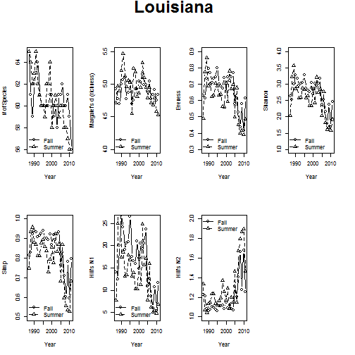

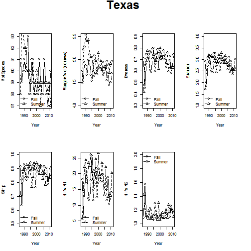

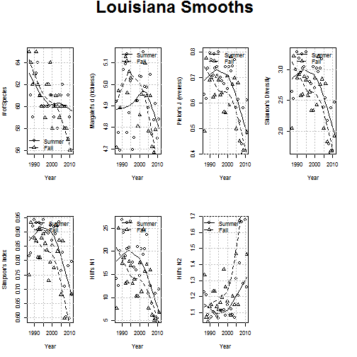

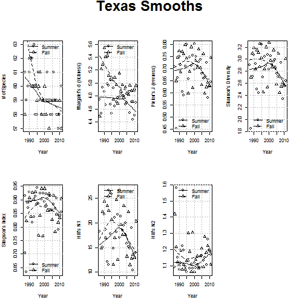

Data frames were created for each of the region/seasonal data sets.

[output not shown]

[output not shown]

[output not shown]

[output not shown]

[output not shown]

[output not shown]

[output not shown]

[output not shown]

[output not shown]

[output not shown]

[output not shown]

[output not shown]

[output not shown]

[output not shown]

[output not shown]

[output not shown]

[output not shown]

[output not shown]

[output not shown]

[output not shown]

[output not shown]

[output not shown]

[output not shown]

[output not shown]

[output not shown]

[output not shown]

[output not shown]

[output not shown]

[output not shown]

[output not shown]

[output not shown]

[output not shown]

[output not shown]

[output not shown]

[output not shown]

[output not shown]

[output not shown]

[output not shown]

[output not shown]

[output not shown]

[output not shown]

[output not shown]

[output not shown]

[output not shown]

[output not shown]

[output not shown]

[output not shown]

[output not shown]

```
## [1] "Break point = 2002"
```

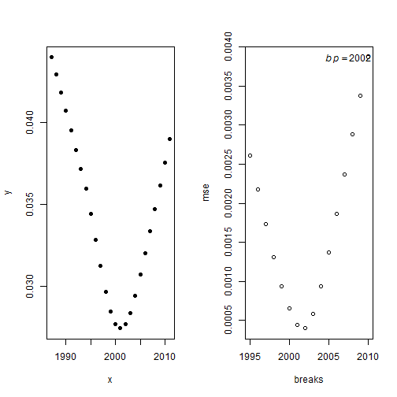

```
##
## Call:
## lm(formula = y ~ x * (x < z) + x * (x > z))
##
## Residuals:
##       Min        1Q    Median        3Q       Max
## -7.08e-04 -1.32e-04 -1.71e-05  2.26e-04  8.73e-04
##
## Coefficients: (1 not defined because of singularities)
##              Estimate Std. Error t value Pr(>|t|)
## (Intercept) -2.65e+00   9.76e-02  -27.18   <2e-16 ***
## x            1.34e-03   4.88e-05   27.46   <2e-16 ***
## x < zTRUE    5.23e+00   1.07e-01   48.65   <2e-16 ***
## x > zTRUE   -8.78e-04   4.67e-04   -1.88    0.075 .
## x:x < zTRUE -2.61e-03   5.37e-05  -48.64   <2e-16 ***
## x:x > zTRUE        NA         NA      NA       NA
## ---
## Signif. codes:  0 '***' 0.001 '**' 0.01 '*' 0.05 '.' 0.1 ' ' 1
##
## Residual standard error: 0.000378 on 20 degrees of freedom
## Multiple R-squared:  0.996,  Adjusted R-squared:  0.995
## F-statistic: 1.11e+03 on 4 and 20 DF,  p-value: <2e-16
```

```
## [1] "Break point = 2000"
```

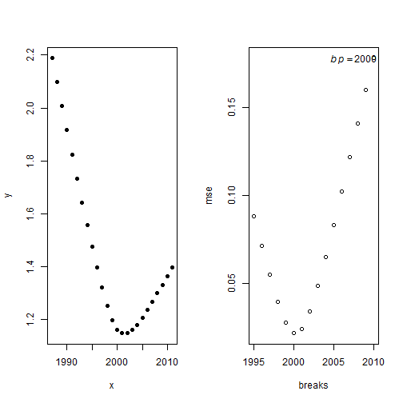

```
##
## Call:
## lm(formula = y ~ x * (x < z) + x * (x > z))
##
## Residuals:
##      Min       1Q   Median       3Q      Max
## -0.02213 -0.01253 -0.00294  0.00908  0.04079
##
## Coefficients: (1 not defined because of singularities)
##              Estimate Std. Error t value Pr(>|t|)
## (Intercept) -51.85246    3.38994  -15.30  1.7e-12 ***
## x             0.02651    0.00169   15.64  1.1e-12 ***
## x < zTRUE   221.74317    4.28819   51.71  < 2e-16 ***
## x > zTRUE    -0.07214    0.02117   -3.41   0.0028 **
## x:x < zTRUE  -0.11092    0.00215  -51.66  < 2e-16 ***
## x:x > zTRUE        NA         NA      NA       NA
## ---
## Signif. codes:  0 '***' 0.001 '**' 0.01 '*' 0.05 '.' 0.1 ' ' 1
##
## Residual standard error: 0.0178 on 20 degrees of freedom
## Multiple R-squared:  0.997,  Adjusted R-squared:  0.997
## F-statistic: 1.97e+03 on 4 and 20 DF,  p-value: <2e-16
```

```
## [1] "Break point = 2001"
```

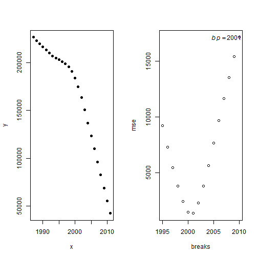

```
##
## Call:
## lm(formula = y ~ x * (x < z) + x * (x > z))
##
## Residuals:
##    Min     1Q Median     3Q    Max
##  -3730   -458      2    247   2392
##
## Coefficients: (1 not defined because of singularities)
##              Estimate Std. Error t value Pr(>|t|)
## (Intercept)  27234290     281624   96.70   <2e-16 ***
## x              -13523        141  -96.08   <2e-16 ***
## x < zTRUE   -21200031     328417  -64.55   <2e-16 ***
## x > zTRUE        2572       1548    1.66     0.11
## x:x < zTRUE     10600        164   64.52   <2e-16 ***
## x:x > zTRUE        NA         NA      NA       NA
## ---
## Signif. codes:  0 '***' 0.001 '**' 0.01 '*' 0.05 '.' 0.1 ' ' 1
##
## Residual standard error: 1280 on 20 degrees of freedom
## Multiple R-squared:     1,   Adjusted R-squared:     1
## F-statistic: 1.22e+04 on 4 and 20 DF,  p-value: <2e-16
```

```
## [1] "Break point = 1996"
```

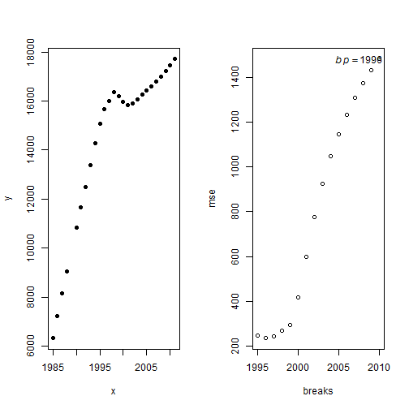

```
##
## Call:
## lm(formula = y ~ x * (x < z) + x * (x > z))
##
## Residuals:
##    Min     1Q Median     3Q    Max
## -387.6  -89.8   -0.4   63.2  530.7
##
## Coefficients: (1 not defined because of singularities)
##              Estimate Std. Error t value Pr(>|t|)
## (Intercept) -2.17e+05   2.86e+04   -7.57  2.0e-07 ***
## x            1.16e+02   1.43e+01    8.11  6.5e-08 ***
## x < zTRUE   -1.52e+06   5.40e+04  -28.08  < 2e-16 ***
## x > zTRUE   -8.23e+01   2.73e+02   -0.30     0.77
## x:x < zTRUE  7.59e+02   2.71e+01   28.02  < 2e-16 ***
## x:x > zTRUE        NA         NA      NA       NA
## ---
## Signif. codes:  0 '***' 0.001 '**' 0.01 '*' 0.05 '.' 0.1 ' ' 1
##
## Residual standard error: 240 on 21 degrees of freedom
## Multiple R-squared:  0.996,  Adjusted R-squared:  0.995
## F-statistic: 1.23e+03 on 4 and 21 DF,  p-value: <2e-16
```

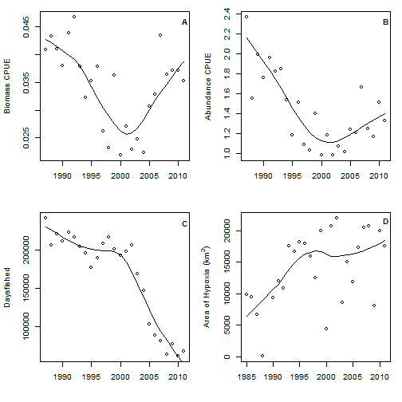

```r
# load the break point function
source("C:\\Users\\Kevin.Purcell\\Documents\\GitHub\\EcosysMetricsGOM\\functions\\breakpts.R")
breakpt.fun(sum.la.S,1,2,1,1)
```

```
## [1] "Break point = 1997"
```

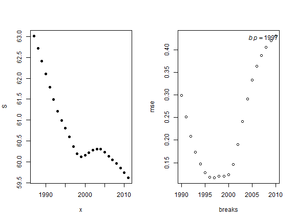

```
##
## Call:
## lm(formula = y ~ x * (x < z) + x * (x > z))
##
## Residuals:
##     Min      1Q  Median      3Q     Max
## -0.2087 -0.0828  0.0000  0.0696  0.1965
##
## Coefficients: (1 not defined because of singularities)
##              Estimate Std. Error t value Pr(>|t|)
## (Intercept) 138.80433   15.82700    8.77  2.7e-08 ***
## x            -0.03928    0.00793   -4.96  7.6e-05 ***
## x < zTRUE   468.78085   30.61719   15.31  1.6e-12 ***
## x > zTRUE     0.01130    0.13727    0.08     0.94
## x:x < zTRUE  -0.23482    0.01536  -15.29  1.7e-12 ***
## x:x > zTRUE        NA         NA      NA       NA
## ---
## Signif. codes:  0 '***' 0.001 '**' 0.01 '*' 0.05 '.' 0.1 ' ' 1
##
## Residual standard error: 0.12 on 20 degrees of freedom
## Multiple R-squared:  0.987,  Adjusted R-squared:  0.985
## F-statistic:  388 on 4 and 20 DF,  p-value: <2e-16
##
## [1] 1997
```

```r
breakpt.fun(sum.la.d,1,2,2,1)
```

```
## [1] "Break point = 2004"
```

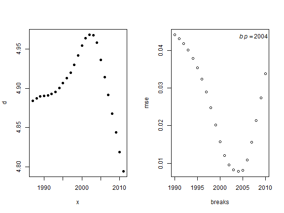

```
##
## Call:
## lm(formula = y ~ x * (x < z) + x * (x > z))
##
## Residuals:
##       Min        1Q    Median        3Q       Max
## -0.011051 -0.005065  0.000077  0.003440  0.013328
##
## Coefficients: (1 not defined because of singularities)
##              Estimate Std. Error t value Pr(>|t|)
## (Intercept)  52.46578    3.03764    17.3  1.7e-13 ***
## x            -0.02371    0.00152   -15.6  1.1e-12 ***
## x < zTRUE   -59.16847    3.13924   -18.9  3.3e-14 ***
## x > zTRUE     0.00312    0.01050     0.3     0.77
## x:x < zTRUE   0.02953    0.00157    18.9  3.3e-14 ***
## x:x > zTRUE        NA         NA      NA       NA
## ---
## Signif. codes:  0 '***' 0.001 '**' 0.01 '*' 0.05 '.' 0.1 ' ' 1
##
## Residual standard error: 0.00802 on 20 degrees of freedom
## Multiple R-squared:  0.972,  Adjusted R-squared:  0.967
## F-statistic:  176 on 4 and 20 DF,  p-value: 2.73e-15
##
## [1] 2004
```

```r
breakpt.fun(sum.la.J,1,2,3,1)
```

```
## [1] "Break point = 2000"
```

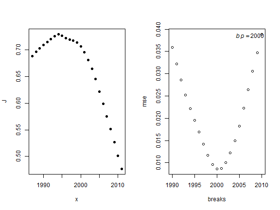

```
##
## Call:
## lm(formula = y ~ x * (x < z) + x * (x > z))
##
## Residuals:
##      Min       1Q   Median       3Q      Max
## -0.01356 -0.00387  0.00130  0.00475  0.01319
##
## Coefficients: (1 not defined because of singularities)
##              Estimate Std. Error t value Pr(>|t|)
## (Intercept)  4.54e+01   1.49e+00   30.44   <2e-16 ***
## x           -2.23e-02   7.46e-04  -29.97   <2e-16 ***
## x < zTRUE   -4.89e+01   1.89e+00  -25.93   <2e-16 ***
## x > zTRUE    2.19e-02   9.31e-03    2.35    0.029 *
## x:x < zTRUE  2.45e-02   9.45e-04   25.91   <2e-16 ***
## x:x > zTRUE        NA         NA      NA       NA
## ---
## Signif. codes:  0 '***' 0.001 '**' 0.01 '*' 0.05 '.' 0.1 ' ' 1
##
## Residual standard error: 0.00782 on 20 degrees of freedom
## Multiple R-squared:  0.992,  Adjusted R-squared:  0.99
## F-statistic:  588 on 4 and 20 DF,  p-value: <2e-16
##
## [1] 2000
```

```r
breakpt.fun(sum.la.shan,1,2,4,1)
```

```
## [1] "Break point = 2000"
```

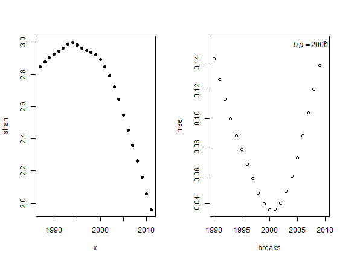

```
##
## Call:
## lm(formula = y ~ x * (x < z) + x * (x > z))
##
## Residuals:
##     Min      1Q  Median      3Q     Max
## -0.0551 -0.0159  0.0052  0.0191  0.0540
##
## Coefficients: (1 not defined because of singularities)
##              Estimate Std. Error t value Pr(>|t|)
## (Intercept)  1.85e+02   6.07e+00   30.47   <2e-16 ***
## x           -9.11e-02   3.04e-03  -30.00   <2e-16 ***
## x < zTRUE   -1.95e+02   7.68e+00  -25.36   <2e-16 ***
## x > zTRUE    8.99e-02   3.79e-02    2.37    0.028 *
## x:x < zTRUE  9.74e-02   3.85e-03   25.34   <2e-16 ***
## x:x > zTRUE        NA         NA      NA       NA
## ---
## Signif. codes:  0 '***' 0.001 '**' 0.01 '*' 0.05 '.' 0.1 ' ' 1
##
## Residual standard error: 0.0318 on 20 degrees of freedom
## Multiple R-squared:  0.992,  Adjusted R-squared:  0.99
## F-statistic:  605 on 4 and 20 DF,  p-value: <2e-16
##
## [1] 2000
```

```r
breakpt.fun(sum.la.simp,1,2,5,1)
```

```
## [1] "Break point = 2000"
```

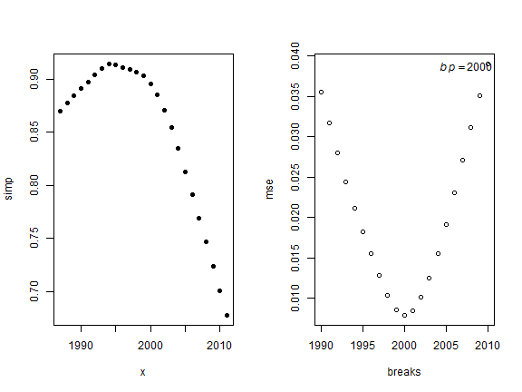

```
##
## Call:
## lm(formula = y ~ x * (x < z) + x * (x > z))
##
## Residuals:
##       Min        1Q    Median        3Q       Max
## -0.014546 -0.002844  0.000792  0.003493  0.012267
##
## Coefficients: (1 not defined because of singularities)
##              Estimate Std. Error t value Pr(>|t|)
## (Intercept)  4.32e+01   1.38e+00   31.36   <2e-16 ***
## x           -2.12e-02   6.89e-04  -30.71   <2e-16 ***
## x < zTRUE   -4.84e+01   1.74e+00  -27.74   <2e-16 ***
## x > zTRUE    1.91e-02   8.61e-03    2.22    0.038 *
## x:x < zTRUE  2.42e-02   8.73e-04   27.72   <2e-16 ***
## x:x > zTRUE        NA         NA      NA       NA
## ---
## Signif. codes:  0 '***' 0.001 '**' 0.01 '*' 0.05 '.' 0.1 ' ' 1
##
## Residual standard error: 0.00723 on 20 degrees of freedom
## Multiple R-squared:  0.992,  Adjusted R-squared:  0.99
## F-statistic:  608 on 4 and 20 DF,  p-value: <2e-16
##
## [1] 2000
```

```r
breakpt.fun(sum.la.N1,1,2,6,1)
```

```
## [1] "Break point = 2000"
```

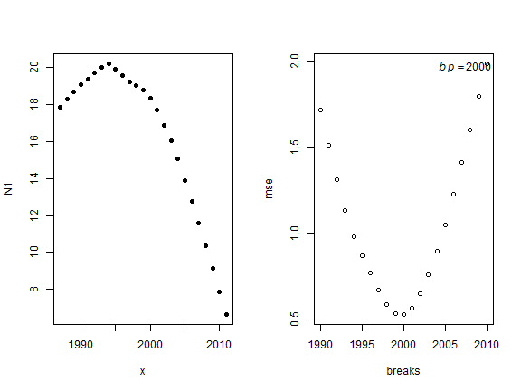

```
##
## Call:
## lm(formula = y ~ x * (x < z) + x * (x > z))
##
## Residuals:
##     Min      1Q  Median      3Q     Max
## -0.9063 -0.2637  0.0726  0.2281  0.9303
##
## Coefficients: (1 not defined because of singularities)
##              Estimate Std. Error t value Pr(>|t|)
## (Intercept)  2.27e+03   9.67e+01   23.52  4.8e-16 ***
## x           -1.13e+00   4.83e-02  -23.33  5.6e-16 ***
## x < zTRUE   -2.42e+03   1.22e+02  -19.75  1.4e-14 ***
## x > zTRUE    9.40e-01   6.04e-01    1.56     0.14
## x:x < zTRUE  1.21e+00   6.12e-02   19.74  1.4e-14 ***
## x:x > zTRUE        NA         NA      NA       NA
## ---
## Signif. codes:  0 '***' 0.001 '**' 0.01 '*' 0.05 '.' 0.1 ' ' 1
##
## Residual standard error: 0.507 on 20 degrees of freedom
## Multiple R-squared:  0.988,  Adjusted R-squared:  0.985
## F-statistic:  401 on 4 and 20 DF,  p-value: <2e-16
##
## [1] 2000
```

```r
breakpt.fun(sum.la.N2,1,2,7,1)
```

```
## [1] "Break point = 1999"
```

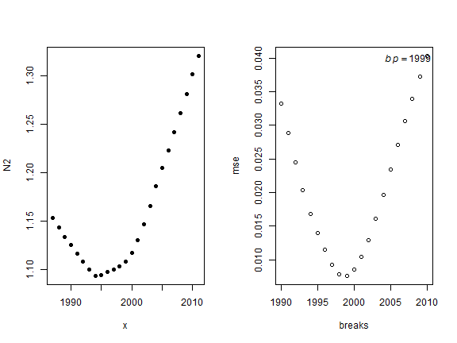

```
##
## Call:
## lm(formula = y ~ x * (x < z) + x * (x > z))
##
## Residuals:
##       Min        1Q    Median        3Q       Max
## -0.013111 -0.002105 -0.000636  0.002151  0.016357
##
## Coefficients: (1 not defined because of singularities)
##              Estimate Std. Error t value Pr(>|t|)
## (Intercept) -3.65e+01   1.21e+00  -30.12   <2e-16 ***
## x            1.88e-02   6.07e-04   31.03   <2e-16 ***
## x < zTRUE    4.76e+01   1.71e+00   27.80   <2e-16 ***
## x > zTRUE   -1.52e-02   8.52e-03   -1.79    0.089 .
## x:x < zTRUE -2.38e-02   8.58e-04  -27.77   <2e-16 ***
## x:x > zTRUE        NA         NA      NA       NA
## ---
## Signif. codes:  0 '***' 0.001 '**' 0.01 '*' 0.05 '.' 0.1 ' ' 1
##
## Residual standard error: 0.00725 on 20 degrees of freedom
## Multiple R-squared:  0.991,  Adjusted R-squared:  0.989
## F-statistic:  563 on 4 and 20 DF,  p-value: <2e-16
##
## [1] 1999
```

```r
breakpt.fun(sum.tx.S,1,2,1,2)
```

```
## [1] "Break point = 1998"
```

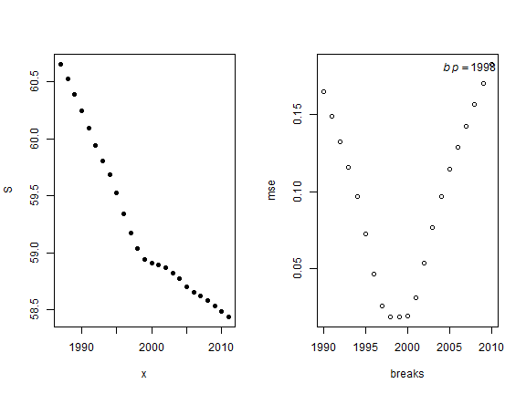

```
##
## Call:
## lm(formula = y ~ x * (x < z) + x * (x > z))
##
## Residuals:
##      Min       1Q   Median       3Q      Max
## -0.03809 -0.00884  0.00052  0.00843  0.03670
##
## Coefficients: (1 not defined because of singularities)
##              Estimate Std. Error t value Pr(>|t|)
## (Intercept) 146.01373    2.78686   52.39   <2e-16 ***
## x            -0.04353    0.00139  -31.21   <2e-16 ***
## x < zTRUE   206.91379    4.53202   45.66   <2e-16 ***
## x > zTRUE    -0.02005    0.02183   -0.92     0.37
## x:x < zTRUE  -0.10355    0.00227  -45.57   <2e-16 ***
## x:x > zTRUE        NA         NA      NA       NA
## ---
## Signif. codes:  0 '***' 0.001 '**' 0.01 '*' 0.05 '.' 0.1 ' ' 1
##
## Residual standard error: 0.0188 on 20 degrees of freedom
## Multiple R-squared:  0.999,  Adjusted R-squared:  0.999
## F-statistic: 8.37e+03 on 4 and 20 DF,  p-value: <2e-16
##
## [1] 1998
```

```r
breakpt.fun(sum.tx.d,1,2,2,2)
```

```
## [1] "Break point = 2003"
```

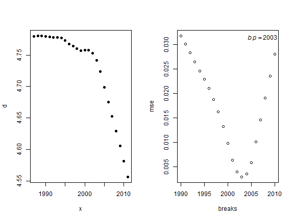

```
##
## Call:
## lm(formula = y ~ x * (x < z) + x * (x > z))
##
## Residuals:
##       Min        1Q    Median        3Q       Max
## -0.006154 -0.001201  0.000044  0.000807  0.006214
##
## Coefficients: (1 not defined because of singularities)
##              Estimate Std. Error t value Pr(>|t|)
## (Intercept)  5.23e+01   8.86e-01    59.0   <2e-16 ***
## x           -2.38e-02   4.43e-04   -53.7   <2e-16 ***
## x < zTRUE   -4.35e+01   9.39e-01   -46.3   <2e-16 ***
## x > zTRUE    5.81e-03   3.64e-03     1.6     0.13
## x:x < zTRUE  2.17e-02   4.69e-04    46.3   <2e-16 ***
## x:x > zTRUE        NA         NA      NA       NA
## ---
## Signif. codes:  0 '***' 0.001 '**' 0.01 '*' 0.05 '.' 0.1 ' ' 1
##
## Residual standard error: 0.00287 on 20 degrees of freedom
## Multiple R-squared:  0.999,  Adjusted R-squared:  0.998
## F-statistic: 3.5e+03 on 4 and 20 DF,  p-value: <2e-16
##
## [1] 2003
```

```r
breakpt.fun(sum.tx.J,1,2,3,2)
```

```
## [1] "Break point = 2002"
```

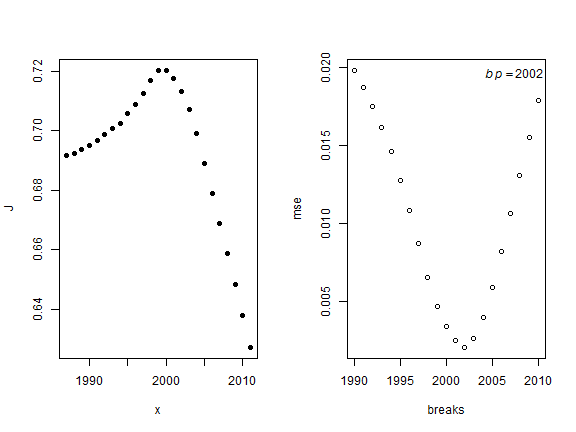

```
##
## Call:
## lm(formula = y ~ x * (x < z) + x * (x > z))
##
## Residuals:
##       Min        1Q    Median        3Q       Max
## -0.003376 -0.001166  0.000160  0.000544  0.003982
##
## Coefficients: (1 not defined because of singularities)
##              Estimate Std. Error t value Pr(>|t|)
## (Intercept)  2.09e+01   4.80e-01   43.62   <2e-16 ***
## x           -1.01e-02   2.40e-04  -42.14   <2e-16 ***
## x < zTRUE   -2.48e+01   5.28e-01  -46.92   <2e-16 ***
## x > zTRUE    5.62e-03   2.29e-03    2.45    0.024 *
## x:x < zTRUE  1.24e-02   2.64e-04   46.91   <2e-16 ***
## x:x > zTRUE        NA         NA      NA       NA
## ---
## Signif. codes:  0 '***' 0.001 '**' 0.01 '*' 0.05 '.' 0.1 ' ' 1
##
## Residual standard error: 0.00186 on 20 degrees of freedom
## Multiple R-squared:  0.996,  Adjusted R-squared:  0.995
## F-statistic: 1.13e+03 on 4 and 20 DF,  p-value: <2e-16
##
## [1] 2002
```

```r
breakpt.fun(sum.tx.shan,1,2,4,2)
```

```
## [1] "Break point = 2002"
```

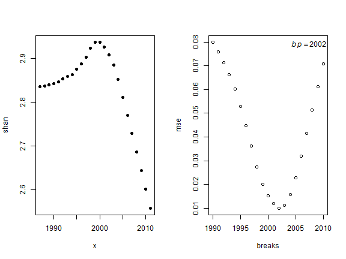

```
##
## Call:
## lm(formula = y ~ x * (x < z) + x * (x > z))
##
## Residuals:
##       Min        1Q    Median        3Q       Max
## -0.014626 -0.006525  0.000575  0.002302  0.018463
##
## Coefficients: (1 not defined because of singularities)
##              Estimate Std. Error t value Pr(>|t|)
## (Intercept)  85.68678    2.38451    35.9   <2e-16 ***
## x            -0.04135    0.00119   -34.7   <2e-16 ***
## x < zTRUE   -99.17417    2.62575   -37.8   <2e-16 ***
## x > zTRUE     0.02396    0.01140     2.1    0.049 *
## x:x < zTRUE   0.04955    0.00131    37.8   <2e-16 ***
## x:x > zTRUE        NA         NA      NA       NA
## ---
## Signif. codes:  0 '***' 0.001 '**' 0.01 '*' 0.05 '.' 0.1 ' ' 1
##
## Residual standard error: 0.00923 on 20 degrees of freedom
## Multiple R-squared:  0.993,  Adjusted R-squared:  0.992
## F-statistic:  758 on 4 and 20 DF,  p-value: <2e-16
##
## [1] 2002
```

```r
breakpt.fun(sum.tx.simp,1,2,5,2)
```

```
## [1] "Break point = 2002"
```

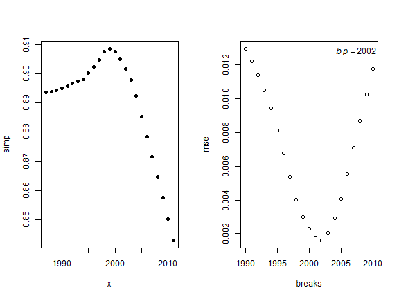

```
##
## Call:
## lm(formula = y ~ x * (x < z) + x * (x > z))
##
## Residuals:
##       Min        1Q    Median        3Q       Max
## -0.003238 -0.000759  0.000113  0.000454  0.002791
##
## Coefficients: (1 not defined because of singularities)
##              Estimate Std. Error t value Pr(>|t|)
## (Intercept)  1.48e+01   3.78e-01   39.11   <2e-16 ***
## x           -6.94e-03   1.89e-04  -36.73   <2e-16 ***
## x < zTRUE   -1.62e+01   4.17e-01  -38.92   <2e-16 ***
## x > zTRUE    4.15e-03   1.81e-03    2.29    0.033 *
## x:x < zTRUE  8.10e-03   2.08e-04   38.91   <2e-16 ***
## x:x > zTRUE        NA         NA      NA       NA
## ---
## Signif. codes:  0 '***' 0.001 '**' 0.01 '*' 0.05 '.' 0.1 ' ' 1
##
## Residual standard error: 0.00146 on 20 degrees of freedom
## Multiple R-squared:  0.995,  Adjusted R-squared:  0.994
## F-statistic:  946 on 4 and 20 DF,  p-value: <2e-16
##
## [1] 2002
```

```r
breakpt.fun(sum.tx.N1,1,2,6,2)
```

```
## [1] "Break point = 2001"
```

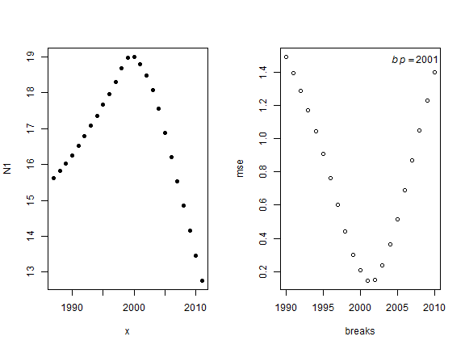

```
##
## Call:
## lm(formula = y ~ x * (x < z) + x * (x > z))
##
## Residuals:
##      Min       1Q   Median       3Q      Max
## -0.24256 -0.07537 -0.00119  0.06315  0.14894
##
## Coefficients: (1 not defined because of singularities)
##              Estimate Std. Error t value Pr(>|t|)
## (Intercept)  1.32e+03   2.27e+01   58.32  < 2e-16 ***
## x           -6.51e-01   1.13e-02  -57.50  < 2e-16 ***
## x < zTRUE   -1.86e+03   2.64e+01  -70.42  < 2e-16 ***
## x > zTRUE    5.85e-01   1.25e-01    4.69  0.00014 ***
## x:x < zTRUE  9.31e-01   1.32e-02   70.37  < 2e-16 ***
## x:x > zTRUE        NA         NA      NA       NA
## ---
## Signif. codes:  0 '***' 0.001 '**' 0.01 '*' 0.05 '.' 0.1 ' ' 1
##
## Residual standard error: 0.103 on 20 degrees of freedom
## Multiple R-squared:  0.997,  Adjusted R-squared:  0.996
## F-statistic: 1.65e+03 on 4 and 20 DF,  p-value: <2e-16
##
## [1] 2001
```

```r
breakpt.fun(sum.tx.N2,1,2,7,2)
```

```
## [1] "Break point = 2002"
```

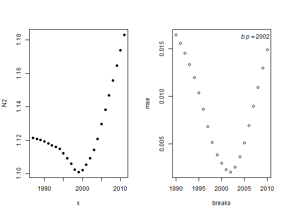

```
##
## Call:
## lm(formula = y ~ x * (x < z) + x * (x > z))
##
## Residuals:
##       Min        1Q    Median        3Q       Max
## -0.003539 -0.000616 -0.000150  0.000978  0.004087
##
## Coefficients: (1 not defined because of singularities)
##              Estimate Std. Error t value Pr(>|t|)
## (Intercept) -1.63e+01   4.83e-01  -33.85   <2e-16 ***
## x            8.72e-03   2.41e-04   36.15   <2e-16 ***
## x < zTRUE    2.06e+01   5.32e-01   38.77   <2e-16 ***
## x > zTRUE   -5.51e-03   2.31e-03   -2.38    0.027 *
## x:x < zTRUE -1.03e-02   2.66e-04  -38.76   <2e-16 ***
## x:x > zTRUE        NA         NA      NA       NA
## ---
## Signif. codes:  0 '***' 0.001 '**' 0.01 '*' 0.05 '.' 0.1 ' ' 1
##
## Residual standard error: 0.00187 on 20 degrees of freedom
## Multiple R-squared:  0.994,  Adjusted R-squared:  0.993
## F-statistic:  890 on 4 and 20 DF,  p-value: <2e-16
##
## [1] 2002
```

```r
breakpt.fun(fall.la.S,1,2,1,3)
```

```
## [1] "Break point = 2001"
```

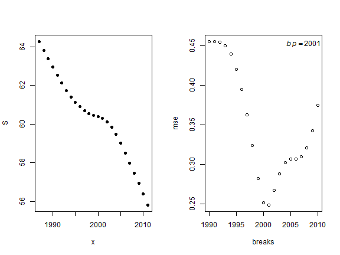

```
##
## Call:
## lm(formula = y ~ x * (x < z) + x * (x > z))
##
## Residuals:
##    Min     1Q Median     3Q    Max
## -0.340 -0.140  0.000  0.109  0.514
##
## Coefficients: (1 not defined because of singularities)
##              Estimate Std. Error t value Pr(>|t|)
## (Intercept) 1039.0838    51.4600   20.19  9.0e-15 ***
## x             -0.4891     0.0257  -19.02  2.8e-14 ***
## x < zTRUE   -362.9926    60.0104   -6.05  6.5e-06 ***
## x > zTRUE      0.5450     0.2829    1.93    0.068 .
## x:x < zTRUE    0.1810     0.0300    6.03  6.8e-06 ***
## x:x > zTRUE        NA         NA      NA       NA
## ---
## Signif. codes:  0 '***' 0.001 '**' 0.01 '*' 0.05 '.' 0.1 ' ' 1
##
## Residual standard error: 0.234 on 20 degrees of freedom
## Multiple R-squared:  0.991,  Adjusted R-squared:  0.989
## F-statistic:  561 on 4 and 20 DF,  p-value: <2e-16
##
## [1] 2001
```

```r
breakpt.fun(fall.la.d,1,2,2,3)
```

```
## [1] "Break point = 2000"
```

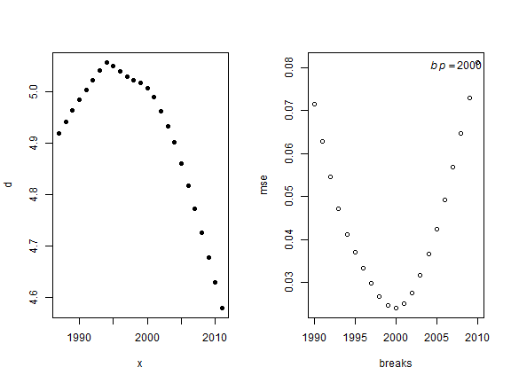

```
##
## Call:
## lm(formula = y ~ x * (x < z) + x * (x > z))
##
## Residuals:
##      Min       1Q   Median       3Q      Max
## -0.04087 -0.01268  0.00229  0.01341  0.04198
##
## Coefficients: (1 not defined because of singularities)
##              Estimate Std. Error t value Pr(>|t|)
## (Intercept)  8.84e+01   4.40e+00   20.07  1.0e-14 ***
## x           -4.17e-02   2.20e-03  -18.93  3.1e-14 ***
## x < zTRUE   -1.00e+02   5.57e+00  -18.02  7.8e-14 ***
## x > zTRUE    4.70e-02   2.75e-02    1.71      0.1
## x:x < zTRUE  5.02e-02   2.79e-03   18.01  7.9e-14 ***
## x:x > zTRUE        NA         NA      NA       NA
## ---
## Signif. codes:  0 '***' 0.001 '**' 0.01 '*' 0.05 '.' 0.1 ' ' 1
##
## Residual standard error: 0.0231 on 20 degrees of freedom
## Multiple R-squared:  0.977,  Adjusted R-squared:  0.973
## F-statistic:  214 on 4 and 20 DF,  p-value: 4.08e-16
##
## [1] 2000
```

```r
breakpt.fun(fall.la.J,1,2,3,3)
```

```
## [1] "Break point = 2004"
```

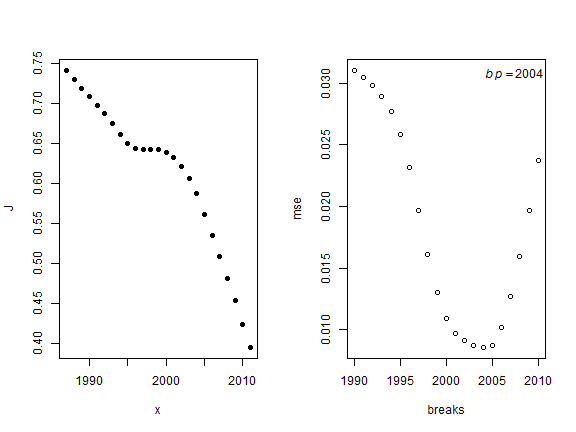

```
##
## Call:
## lm(formula = y ~ x * (x < z) + x * (x > z))
##
## Residuals:
##      Min       1Q   Median       3Q      Max
## -0.01729 -0.00210  0.00000  0.00569  0.01277
##
## Coefficients: (1 not defined because of singularities)
##              Estimate Std. Error t value Pr(>|t|)
## (Intercept)  56.06952    3.32428   16.87  2.7e-13 ***
## x            -0.02769    0.00166  -16.69  3.3e-13 ***
## x < zTRUE   -39.94514    3.43547  -11.63  2.4e-10 ***
## x > zTRUE     0.00285    0.01149    0.25     0.81
## x:x < zTRUE   0.01994    0.00171   11.63  2.4e-10 ***
## x:x > zTRUE        NA         NA      NA       NA
## ---
## Signif. codes:  0 '***' 0.001 '**' 0.01 '*' 0.05 '.' 0.1 ' ' 1
##
## Residual standard error: 0.00878 on 20 degrees of freedom
## Multiple R-squared:  0.993,  Adjusted R-squared:  0.992
## F-statistic:  714 on 4 and 20 DF,  p-value: <2e-16
##
## [1] 2004
```

```r
breakpt.fun(fall.la.shan,1,2,4,3)
```

```
## [1] "Break point = 2004"
```

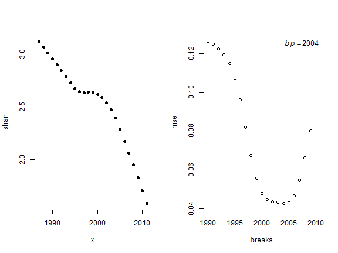

```
##
## Call:
## lm(formula = y ~ x * (x < z) + x * (x > z))
##
## Residuals:
##      Min       1Q   Median       3Q      Max
## -0.08249 -0.00873  0.00000  0.02532  0.07013
##
## Coefficients: (1 not defined because of singularities)
##              Estimate Std. Error t value Pr(>|t|)
## (Intercept)  2.37e+02   1.66e+01   14.33  5.6e-12 ***
## x           -1.17e-01   8.26e-03  -14.19  6.7e-12 ***
## x < zTRUE   -1.60e+02   1.71e+01   -9.33  9.9e-09 ***
## x > zTRUE    1.22e-02   5.72e-02    0.21     0.83
## x:x < zTRUE  7.97e-02   8.54e-03    9.33  1.0e-08 ***
## x:x > zTRUE        NA         NA      NA       NA
## ---
## Signif. codes:  0 '***' 0.001 '**' 0.01 '*' 0.05 '.' 0.1 ' ' 1
##
## Residual standard error: 0.0437 on 20 degrees of freedom
## Multiple R-squared:  0.991,  Adjusted R-squared:  0.989
## F-statistic:  562 on 4 and 20 DF,  p-value: <2e-16
##
## [1] 2004
```

```r
breakpt.fun(fall.la.simp,1,2,5,3)
```

```
## [1] "Break point = 2002"
```

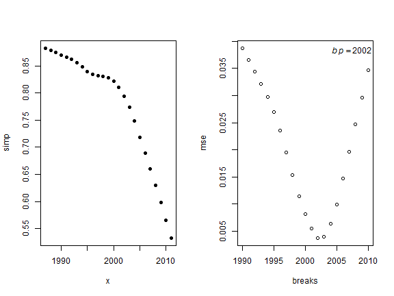

```
##
## Call:
## lm(formula = y ~ x * (x < z) + x * (x > z))
##
## Residuals:
##       Min        1Q    Median        3Q       Max
## -0.004914 -0.001521  0.000531  0.002161  0.004027
##
## Coefficients: (1 not defined because of singularities)
##              Estimate Std. Error t value Pr(>|t|)
## (Intercept)  6.14e+01   7.28e-01   84.31  < 2e-16 ***
## x           -3.03e-02   3.64e-04  -83.22  < 2e-16 ***
## x < zTRUE   -5.04e+01   8.01e-01  -62.95  < 2e-16 ***
## x > zTRUE    1.42e-02   3.48e-03    4.08  0.00059 ***
## x:x < zTRUE  2.52e-02   4.01e-04   62.92  < 2e-16 ***
## x:x > zTRUE        NA         NA      NA       NA
## ---
## Signif. codes:  0 '***' 0.001 '**' 0.01 '*' 0.05 '.' 0.1 ' ' 1
##
## Residual standard error: 0.00282 on 20 degrees of freedom
## Multiple R-squared:  0.999,  Adjusted R-squared:  0.999
## F-statistic: 8.5e+03 on 4 and 20 DF,  p-value: <2e-16
##
## [1] 2002
```

```r
breakpt.fun(fall.la.N1,1,2,6,3)
```

```
## [1] "Break point = 2000"
```

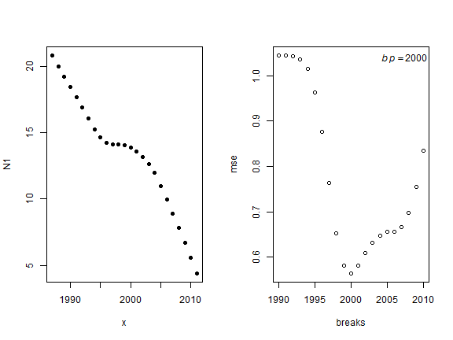

```
##
## Call:
## lm(formula = y ~ x * (x < z) + x * (x > z))
##
## Residuals:
##    Min     1Q Median     3Q    Max
## -0.763 -0.290  0.000  0.345  1.119
##
## Coefficients: (1 not defined because of singularities)
##              Estimate Std. Error t value Pr(>|t|)
## (Intercept) 1908.4031    98.0560   19.46  1.8e-14 ***
## x             -0.9473     0.0490  -19.32  2.1e-14 ***
## x < zTRUE   -676.4883   124.0383   -5.45  2.4e-05 ***
## x > zTRUE      1.4057     0.6124    2.30    0.033 *
## x:x < zTRUE    0.3375     0.0621    5.43  2.6e-05 ***
## x:x > zTRUE        NA         NA      NA       NA
## ---
## Signif. codes:  0 '***' 0.001 '**' 0.01 '*' 0.05 '.' 0.1 ' ' 1
##
## Residual standard error: 0.514 on 20 degrees of freedom
## Multiple R-squared:  0.989,  Adjusted R-squared:  0.986
## F-statistic:  432 on 4 and 20 DF,  p-value: <2e-16
##
## [1] 2000
```

```r
breakpt.fun(fall.la.N2,1,2,7,3)
```

```
## [1] "Break point = 2002"
```

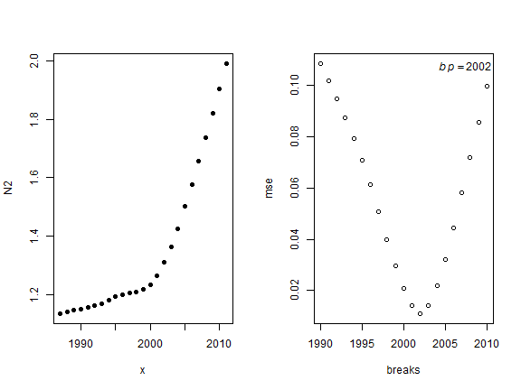

```
##
## Call:
## lm(formula = y ~ x * (x < z) + x * (x > z))
##
## Residuals:
##      Min       1Q   Median       3Q      Max
## -0.00825 -0.00532 -0.00218  0.00267  0.02231
##
## Coefficients: (1 not defined because of singularities)
##              Estimate Std. Error t value Pr(>|t|)
## (Intercept) -1.57e+02   2.20e+00   -71.2  < 2e-16 ***
## x            7.90e-02   1.10e-03    71.8  < 2e-16 ***
## x < zTRUE    1.42e+02   2.43e+00    58.4  < 2e-16 ***
## x > zTRUE   -4.11e-02   1.05e-02    -3.9  0.00089 ***
## x:x < zTRUE -7.08e-02   1.21e-03   -58.4  < 2e-16 ***
## x:x > zTRUE        NA         NA      NA       NA
## ---
## Signif. codes:  0 '***' 0.001 '**' 0.01 '*' 0.05 '.' 0.1 ' ' 1
##
## Residual standard error: 0.00853 on 20 degrees of freedom
## Multiple R-squared:  0.999,  Adjusted R-squared:  0.999
## F-statistic: 5.8e+03 on 4 and 20 DF,  p-value: <2e-16
##
## [1] 2002
```

```r
breakpt.fun(fall.tx.S,1,2,1,4)
```

```
## [1] "Break point = 1997"
```

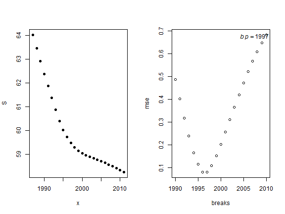

```
##
## Call:
## lm(formula = y ~ x * (x < z) + x * (x > z))
##
## Residuals:
##     Min      1Q  Median      3Q     Max
## -0.0951 -0.0355  0.0000  0.0120  0.2131
##
## Coefficients: (1 not defined because of singularities)
##              Estimate Std. Error t value Pr(>|t|)
## (Intercept) 206.98817    9.96283   20.78  5.2e-15 ***
## x            -0.07386    0.00499  -14.81  3.1e-12 ***
## x < zTRUE   821.86405   19.27300   42.64  < 2e-16 ***
## x > zTRUE    -0.18429    0.08641   -2.13    0.046 *
## x:x < zTRUE  -0.41178    0.00967  -42.58  < 2e-16 ***
## x:x > zTRUE        NA         NA      NA       NA
## ---
## Signif. codes:  0 '***' 0.001 '**' 0.01 '*' 0.05 '.' 0.1 ' ' 1
##
## Residual standard error: 0.0752 on 20 degrees of freedom
## Multiple R-squared:  0.998,  Adjusted R-squared:  0.998
## F-statistic: 3.17e+03 on 4 and 20 DF,  p-value: <2e-16
##
## [1] 1997
```

```r
breakpt.fun(fall.tx.d,1,2,2,4)
```

```
## [1] "Break point = 2000"
```

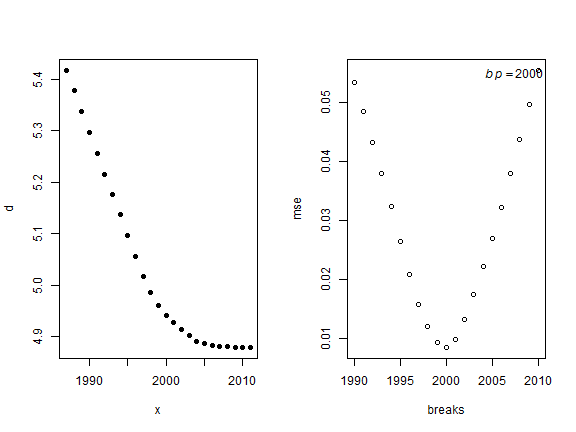

```
##
## Call:
## lm(formula = y ~ x * (x < z) + x * (x > z))
##
## Residuals:
##      Min       1Q   Median       3Q      Max
## -0.00932 -0.00526 -0.00188  0.00398  0.01642
##
## Coefficients: (1 not defined because of singularities)
##              Estimate Std. Error t value Pr(>|t|)
## (Intercept) 13.609056   1.390151    9.79  4.5e-09 ***
## x           -0.004334   0.000695   -6.23  4.3e-06 ***
## x < zTRUE   69.544968   1.758505   39.55  < 2e-16 ***
## x > zTRUE   -0.024759   0.008681   -2.85   0.0099 **
## x:x < zTRUE -0.034791   0.000880  -39.52  < 2e-16 ***
## x:x > zTRUE        NA         NA      NA       NA
## ---
## Signif. codes:  0 '***' 0.001 '**' 0.01 '*' 0.05 '.' 0.1 ' ' 1
##
## Residual standard error: 0.00729 on 20 degrees of freedom
## Multiple R-squared:  0.999,  Adjusted R-squared:  0.998
## F-statistic: 3.7e+03 on 4 and 20 DF,  p-value: <2e-16
##
## [1] 2000
```

```r
breakpt.fun(fall.tx.J,1,2,3,4)
```

```
## [1] "Break point = 1998"
```

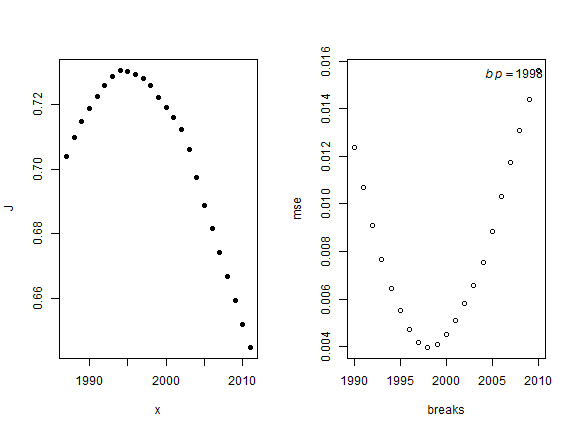

```
##
## Call:
## lm(formula = y ~ x * (x < z) + x * (x > z))
##
## Residuals:
##       Min        1Q    Median        3Q       Max
## -0.006648 -0.001974  0.000177  0.002909  0.004718
##
## Coefficients: (1 not defined because of singularities)
##              Estimate Std. Error t value Pr(>|t|)
## (Intercept)  1.44e+01   5.32e-01   27.06  < 2e-16 ***
## x           -6.84e-03   2.66e-04  -25.69  < 2e-16 ***
## x < zTRUE   -1.87e+01   8.65e-01  -21.57  2.5e-15 ***
## x > zTRUE    9.83e-03   4.17e-03    2.36    0.029 *
## x:x < zTRUE  9.35e-03   4.34e-04   21.54  2.6e-15 ***
## x:x > zTRUE        NA         NA      NA       NA
## ---
## Signif. codes:  0 '***' 0.001 '**' 0.01 '*' 0.05 '.' 0.1 ' ' 1
##
## Residual standard error: 0.00359 on 20 degrees of freedom
## Multiple R-squared:  0.985,  Adjusted R-squared:  0.982
## F-statistic:  324 on 4 and 20 DF,  p-value: <2e-16
##
## [1] 1998
```

```r
breakpt.fun(fall.tx.shan,1,2,4,4)
```

```
## [1] "Break point = 2000"
```

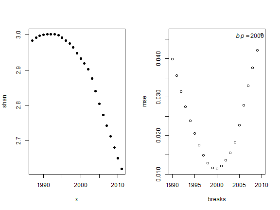

```
##
## Call:
## lm(formula = y ~ x * (x < z) + x * (x > z))
##
## Residuals:
##       Min        1Q    Median        3Q       Max
## -0.023259 -0.001571 -0.000402  0.004831  0.013694
##
## Coefficients: (1 not defined because of singularities)
##              Estimate Std. Error t value Pr(>|t|)
## (Intercept)  6.48e+01   1.97e+00    32.9  < 2e-16 ***
## x           -3.09e-02   9.85e-04   -31.4  < 2e-16 ***
## x < zTRUE   -5.62e+01   2.49e+00   -22.6  1.1e-15 ***
## x > zTRUE    2.83e-02   1.23e-02     2.3    0.032 *
## x:x < zTRUE  2.81e-02   1.25e-03    22.5  1.1e-15 ***
## x:x > zTRUE        NA         NA      NA       NA
## ---
## Signif. codes:  0 '***' 0.001 '**' 0.01 '*' 0.05 '.' 0.1 ' ' 1
##
## Residual standard error: 0.0103 on 20 degrees of freedom
## Multiple R-squared:  0.994,  Adjusted R-squared:  0.993
## F-statistic:  885 on 4 and 20 DF,  p-value: <2e-16
##
## [1] 2000
```

```r
breakpt.fun(fall.tx.simp,1,2,5,4)
```

```
## [1] "Break point = 1995"
```

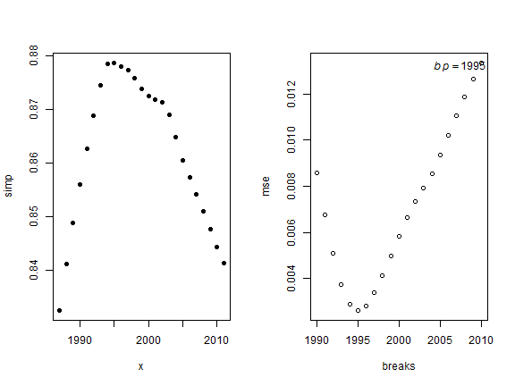

```
##
## Call:
## lm(formula = y ~ x * (x < z) + x * (x > z))
##
## Residuals:
##      Min       1Q   Median       3Q      Max
## -0.00419 -0.00153  0.00000  0.00122  0.00456
##
## Coefficients: (1 not defined because of singularities)
##              Estimate Std. Error t value Pr(>|t|)
## (Intercept)  5.96e+00   2.59e-01   23.07  7.0e-16 ***
## x           -2.55e-03   1.30e-04  -19.67  1.5e-14 ***
## x < zTRUE   -1.83e+01   7.78e-01  -23.49  4.9e-16 ***
## x > zTRUE    6.09e-03   2.70e-03    2.26    0.035 *
## x:x < zTRUE  9.17e-03   3.91e-04   23.46  5.0e-16 ***
## x:x > zTRUE        NA         NA      NA       NA
## ---
## Signif. codes:  0 '***' 0.001 '**' 0.01 '*' 0.05 '.' 0.1 ' ' 1
##
## Residual standard error: 0.00239 on 20 degrees of freedom
## Multiple R-squared:  0.975,  Adjusted R-squared:  0.97
## F-statistic:  196 on 4 and 20 DF,  p-value: 9.53e-16
##
## [1] 1995
```

```r
breakpt.fun(fall.tx.N1,1,2,6,4)
```

```
## [1] "Break point = 1996"
```

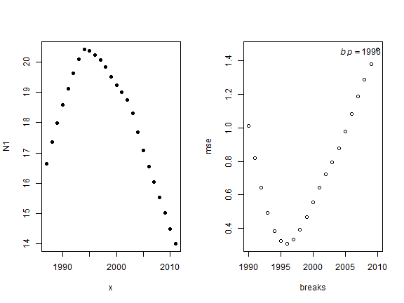

```
##
## Call:
## lm(formula = y ~ x * (x < z) + x * (x > z))
##
## Residuals:
##     Min      1Q  Median      3Q     Max
## -0.5010 -0.1445  0.0234  0.2033  0.4440
##
## Coefficients: (1 not defined because of singularities)
##              Estimate Std. Error t value Pr(>|t|)
## (Intercept)  9.23e+02   3.31e+01    27.9  < 2e-16 ***
## x           -4.52e-01   1.66e-02   -27.3  < 2e-16 ***
## x < zTRUE   -1.88e+03   7.85e+01   -24.0  3.3e-16 ***
## x > zTRUE    7.87e-01   3.15e-01     2.5    0.021 *
## x:x < zTRUE  9.44e-01   3.94e-02    23.9  3.4e-16 ***
## x:x > zTRUE        NA         NA      NA       NA
## ---
## Signif. codes:  0 '***' 0.001 '**' 0.01 '*' 0.05 '.' 0.1 ' ' 1
##
## Residual standard error: 0.277 on 20 degrees of freedom
## Multiple R-squared:  0.983,  Adjusted R-squared:  0.98
## F-statistic:  291 on 4 and 20 DF,  p-value: <2e-16
##
## [1] 1996
```

```r
breakpt.fun(fall.tx.N2,1,2,7,4)
```

```
## [1] "Break point = 1995"
```

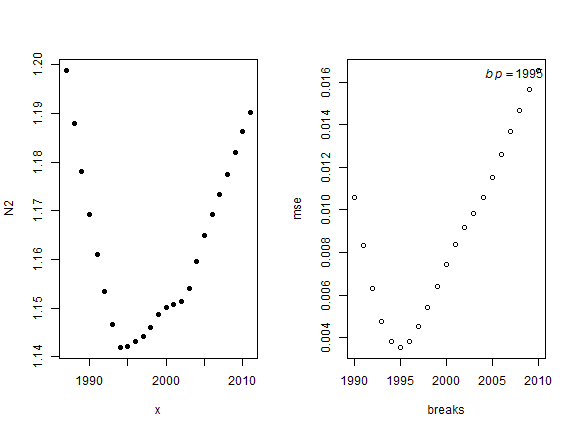

```
##
## Call:
## lm(formula = y ~ x * (x < z) + x * (x > z))
##
## Residuals:
##       Min        1Q    Median        3Q       Max
## -0.006213 -0.001835 -0.000039  0.002110  0.005576
##
## Coefficients: (1 not defined because of singularities)
##              Estimate Std. Error t value Pr(>|t|)
## (Intercept) -5.334009   0.355776   -15.0  2.4e-12 ***
## x            0.003246   0.000178    18.2  6.5e-14 ***
## x < zTRUE   22.796655   1.070767    21.3  3.3e-15 ***
## x > zTRUE   -0.007786   0.003713    -2.1    0.049 *
## x:x < zTRUE -0.011433   0.000538   -21.3  3.4e-15 ***
## x:x > zTRUE        NA         NA      NA       NA
## ---
## Signif. codes:  0 '***' 0.001 '**' 0.01 '*' 0.05 '.' 0.1 ' ' 1
##
## Residual standard error: 0.00329 on 20 degrees of freedom
## Multiple R-squared:  0.97,   Adjusted R-squared:  0.964
## F-statistic:  161 on 4 and 20 DF,  p-value: 6.39e-15
##
## [1] 1995
```

```r
breakpt.tab<-rbind(sum.la_S, sum.la_d, sum.la_J, sum.la_shan, sum.la_simp, sum.la_N1, sum.la_N2,
                   sum.tx_S, sum.tx_d, sum.tx_J, sum.tx_shan, sum.tx_simp, sum.tx_N1, sum.tx_N2,
                   fall.la_S, fall.la_d, fall.la_J, fall.la_shan, fall.la_simp, fall.la_N1, fall.la_N2,
                   fall.tx_S, fall.tx_d, fall.tx_J, fall.tx_shan, fall.tx_simp, fall.tx_N1, fall.tx_N2)
#bind the model output tables
rm(sum.la_S, sum.la_d, sum.la_J, sum.la_shan, sum.la_simp, sum.la_N1, sum.la_N2,
                   sum.tx_S, sum.tx_d, sum.tx_J, sum.tx_shan, sum.tx_simp, sum.tx_N1, sum.tx_N2,
                   fall.la_S, fall.la_d, fall.la_J, fall.la_shan, fall.la_simp, fall.la_N1, fall.la_N2,
                   fall.tx_S, fall.tx_d, fall.tx_J, fall.tx_shan, fall.tx_simp, fall.tx_N1, fall.tx_N2)
```

```r
pandoc.table(breakpt.tab, style="rmarkdown")
```

| mod | stat | alpha | p.Val | r.Sqr |
| --- | --- | --- | --- | --- |
| sum.la | S | 1997 | 1.31e-19 | 0.9873 |
| sum.la | d | 2004 | 0.0002485 | 0.9724 |
| sum.la | J | 2000 | 1.341e-20 | 0.9916 |
| sum.la | shan | 2000 | 7.232e-21 | 0.9918 |
| sum.la | simp | 2000 | 1.671e-20 | 0.9918 |
| sum.la | N1 | 2000 | 3.197e-19 | 0.9877 |
| sum.la | N2 | 1999 | 4.741e-20 | 0.9912 |
| sum.tx | S | 1998 | 2.187e-33 | 0.9994 |
| sum.tx | d | 2003 | 1.004e-28 | 0.9986 |
| sum.tx | J | 2002 | 3.282e-20 | 0.9956 |
| sum.tx | shan | 2002 | 6.121e-19 | 0.9935 |
| sum.tx | simp | 2002 | 8.883e-21 | 0.9947 |
| sum.tx | N1 | 2001 | 4.224e-17 | 0.997 |
| sum.tx | N2 | 2002 | 3.067e-20 | 0.9944 |
| fall.la | S | 2001 | 6.789e-22 | 0.9912 |
| fall.la | d | 2000 | 1.263e-15 | 0.9772 |
| fall.la | J | 2004 | 1.212e-22 | 0.993 |
| fall.la | shan | 2004 | 1.069e-21 | 0.9912 |
| fall.la | simp | 2002 | 4.636e-33 | 0.9994 |
| fall.la | N1 | 2000 | 1.017e-20 | 0.9886 |
| fall.la | N2 | 2002 | 3.683e-31 | 0.9991 |
| fall.tx | S | 1997 | 9.455e-29 | 0.9984 |
| fall.tx | d | 2000 | 1.233e-29 | 0.9987 |
| fall.tx | J | 1998 | 1.403e-17 | 0.9848 |
| fall.tx | shan | 2000 | 3.028e-23 | 0.9944 |
| fall.tx | simp | 1995 | 0.003069 | 0.9752 |
| fall.tx | N1 | 1996 | 2.83e-15 | 0.9831 |
| fall.tx | N2 | 1995 | 0.0005285 | 0.97 |